# Ordinal Model Code

Let panel be a given DF. A theory of causality between income and depression (PHQDEP) is being formed here. for background, PHQDEP is a depression survey which ranks peoples severity of symptoms from 0 to 3. larger numbers here imply greater depressive symptoms.

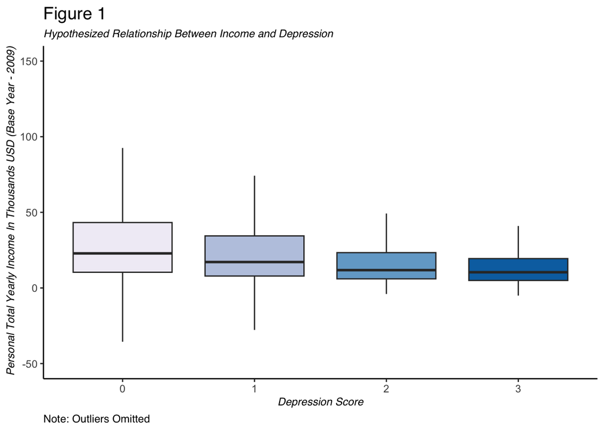

```r
#Creation of bar plots comparing income and PHQDEP scores
panel.A <- subset(panel, !is.na(panel$PHQDEP))
plot.1 <- ggplot(panel.A, aes(x = as.factor(PHQDEP), y = INCTOT, fill = as.factor(PHQDEP))) +
  geom_boxplot(size = .5,outlier.shape = NA) +
  coord_cartesian(ylim=c(-50, 150)) +
  theme_classic() +
  labs( x = "Depression Score", y = " Personal Total Yearly Income In Thousands USD (Base Year - 2009)", title = "Figure 1",subtitle = "Hypothesized Relationship Between Income and Depression",caption  = "Note: Outliers Omitted",fontface="italic") +
  theme(
       title = element_text(family = "sans",size = 12),
       axis.title.x = element_text(family = "sans",size = 9,face = "italic"),
       axis.title.y = element_text(family = "sans",size = 9,face = "italic"),
       plot.subtitle = element_text(family = "sans",size = 9,face = "italic"),
       plot.caption = element_text(family = "sans",size = 9,hjust = 0))+
  scale_fill_brewer(palette="PuBu",breaks = "PHQDEP")
plot.1
```

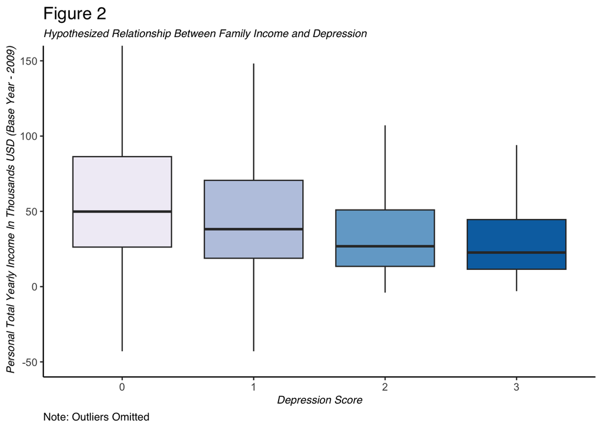

```r
plot.2 <- ggplot(panel.A, aes(x = as.factor(PHQDEP), y = FTOTINCMEPS, fill = as.factor(PHQDEP))) +
  geom_boxplot(size = .5,outlier.shape = NA) +
  coord_cartesian(ylim=c(-50, 150)) +
  theme_classic() +
  labs( x = "Depression Score", y = " Personal Total Yearly Income In Thousands USD (Base Year - 2009)", title = "Figure 2",subtitle = "Hypothesized Relationship Between Family Income and Depression",caption  = "Note: Outliers Omitted",fontface="italic") +
  theme(
    title = element_text(family = "sans",size = 12),
    axis.title.x = element_text(family = "sans",size = 9,face = "italic"),
    axis.title.y = element_text(family = "sans",size = 9,face = "italic"),
    plot.subtitle = element_text(family = "sans",size = 9,face = "italic"),
    plot.caption = element_text(family = "sans",size = 9,hjust = 0))+
  scale_fill_brewer(palette="PuBu",breaks = "PHQDEP")
plot.2
```

Formatting data into the right types, of particular importance is making response variables **ranked** factors

```r
# simply here to format data into right types
panel$YEAR <- as.factor(panel$YEAR)
panel$MEPSID <- as.factor(panel$MEPSID)
panel$DUID <- as.factor(panel$DUID)
panel$REGIONMEPS <- as.factor(panel$REGIONMEPS)
panel$SEX <- as.factor(panel$SEX)
panel$MARSTAT <- as.factor(panel$MARSTAT)
panel$HEALTH <- as.factor(panel$HEALTH)
panel$EDUC <- as.factor(panel$EDUC)
panel$AEFFORT <- factor(panel$AEFFORT,levels = c(0,1,2,3,4))
panel$AHOPELESS <- factor(panel$AHOPELESS,levels = c(0,1,2,3,4))
panel$ANERVOUS <- factor(panel$ANERVOUS,levels = c(0,1,2,3,4))
panel$ARESTLESS <- factor(panel$ARESTLESS,levels = c(0,1,2,3,4))
panel$ASAD <- factor(panel$ASAD,levels = c(0,1,2,3,4))
panel$AWORTHLESS <- factor(panel$AWORTHLESS,levels = c(0,1,2,3,4))
panel$PHQINTR <- factor(panel$PHQINTR,levels = c(0,1,2,3))
panel$PHQDEP <- factor(panel$PHQDEP,levels = c(0,1,2,3))
panel$SMOKENOW <- as.factor(panel$SMOKENOW)
panel$RACEA <- as.factor(panel$RACEA)
panel$OCCCATRD <- as.factor(panel$OCCCATRD) #Maybe dont use b/c of DF loss
panel$CANCEREV <- as.factor(panel$CANCEREV)
panel$INSULIN <- as.factor(panel$INSULIN)
panel$INTERVLANG <- as.factor(panel$INTERVLANG)
```

Here shows initial fitting of ordinal logit w/o controls

```r
QDEP.2 <- polr(PHQDEP ~ INCTOT, data = panel, Hess = TRUE)
summary(QDEP.2)
```

```
## Call:
## polr(formula = PHQDEP ~ INCTOT, data = panel, Hess = TRUE)
##
## Coefficients:
##           Value Std. Error t value
## INCTOT -0.01161  0.0002244  -51.72
##
## Intercepts:
##     Value    Std. Error t value
## 0|1   0.8840   0.0078   113.0047
## 1|2   2.3138   0.0106   217.7012
## 2|3   3.3310   0.0155   214.5403
##
## Residual Deviance: 265414.87
## AIC: 265422.87
## (33007 observations deleted due to missingness)
```

```r
AEFT.2 <- polr(AEFFORT ~ INCTOT, data = panel, Hess = TRUE)

AHOPS.2 <- polr(AHOPELESS ~ INCTOT, data = panel, Hess = TRUE)

ARES.2 <- polr(ARESTLESS ~ INCTOT, data = panel, Hess = TRUE)

ASAD.2 <- polr(ASAD ~ INCTOT, data = panel, Hess = TRUE)

AWORS.2 <- polr(AWORTHLESS ~ INCTOT, data = panel, Hess = TRUE)

QINTR.2 <- polr(PHQINTR ~ INCTOT, data = panel, Hess = TRUE)
```

Here shows initial fitting of the ordinal logit with controls .

```r
#Fitting of first models, no instruments are used here


QDEP.3 <- polr(PHQDEP ~ INCTOT +  FTOTINCMEPS + YEAR + REGIONMEPS +SEX + MARSTAT + HEALTH +
                  EDUC + SMOKENOW + RACEA + CANCEREV + INTERVLANG + FAMSIZE +ANERVOUS,
                  data = panel, Hess = TRUE)
summary(QDEP.3)
```

```
## Call:
## polr(formula = PHQDEP ~ INCTOT + FTOTINCMEPS + YEAR + REGIONMEPS +
##     SEX + MARSTAT + HEALTH + EDUC + SMOKENOW + RACEA + CANCEREV +
##     INTERVLANG + FAMSIZE + ANERVOUS, data = panel, Hess = TRUE)
##
## Coefficients:
##                  Value Std. Error    t value
## INCTOT      -0.0022757  0.0003592  -6.335012
## FTOTINCMEPS -0.0019918  0.0002139  -9.310282
## YEAR2011    -0.0027545  0.0264403  -0.104176
## YEAR2012    -0.0246421  0.0259926  -0.948043
## YEAR2013    -0.1187340  0.0296817  -4.000236
## YEAR2014    -0.1112653  0.0300689  -3.700351
## YEAR2015    -0.1506766  0.0280279  -5.375942
## YEAR2016    -0.1476919  0.0278531  -5.302525
## YEAR2017    -0.1502885  0.0284079  -5.290384
## REGIONMEPS1 -1.1126462  0.0214967 -51.758967
## REGIONMEPS2 -1.1522726  0.0204258 -56.412549
## REGIONMEPS3 -1.1242200  0.0189067 -59.461337
## REGIONMEPS4 -1.1273790  0.0199792 -56.427502
## SEX2         0.1282346  0.0143905   8.911060
## MARSTAT20    0.0862000  0.0291435   2.957774
## MARSTAT30    0.2419281  0.0222551  10.870667
## MARSTAT40    0.3304022  0.0373037   8.857091
## MARSTAT50    0.1992121  0.0172814  11.527553
## HEALTH2      0.4370037  0.0266691  16.386158
## HEALTH3      0.9590594  0.0260510  36.814715
## HEALTH4      1.6285125  0.0285939  56.953090
## HEALTH5      2.3571170  0.0395735  59.562996
## EDUC101     -0.0067424  0.0877073  -0.076873
## EDUC102      0.0990552  0.1230130   0.805242
## EDUC104      0.2914139  0.1686169   1.728260
## EDUC105      0.2084143  0.1431402   1.456015
## EDUC106     -0.1645287  0.1187929  -1.385005
## EDUC107      0.1151711  0.1238959   0.929579
## EDUC108      0.0411951  0.1207847   0.341063
## EDUC109     -0.1020679  0.0859642  -1.187331
## EDUC110      0.0613136  0.1087606   0.563748
## EDUC111      0.0592773  0.0870043   0.681314
## EDUC112     -0.0103549  0.0708813  -0.146088
```

[output cut: 26 more lines]

```
## FAMSIZE      0.0123041  0.0048342   2.545198
## ANERVOUS1    1.4503898  0.0181639  79.850276
## ANERVOUS2    2.6900384  0.0199820 134.622995
## ANERVOUS3    4.0032781  0.0307326 130.261542
## ANERVOUS4    4.8262532  0.0485948  99.316227
##
## Intercepts:
##     Value    Std. Error t value
## 0|1   2.2213   0.0620    35.8304
## 1|2   4.3304   0.0634    68.2973
## 2|3   5.7000   0.0654    87.2016
##
## Residual Deviance: 172110.82
## AIC: 172244.82
## (58042 observations deleted due to missingness)
```

```r
AEFT.3 <-polr(AEFFORT ~ INCTOT + FTOTINCMEPS + YEAR + REGIONMEPS +SEX + MARSTAT + HEALTH +
                           EDUC + SMOKENOW + RACEA + CANCEREV + INTERVLANG + FAMSIZE + ANERVOUS,
                          data = panel, Hess = TRUE)
AHOPS.3 <-polr(AHOPELESS ~ INCTOT + FTOTINCMEPS + YEAR + REGIONMEPS +SEX + MARSTAT + HEALTH +
                         EDUC + SMOKENOW + RACEA + CANCEREV + INTERVLANG + FAMSIZE + ANERVOUS,
                       data = panel, Hess = TRUE)
ARES.3 <-polr(ARESTLESS ~ INCTOT + FTOTINCMEPS + YEAR + REGIONMEPS +SEX + MARSTAT + HEALTH +
                         EDUC + SMOKENOW + RACEA + CANCEREV + INTERVLANG + FAMSIZE + ANERVOUS,
                       data = panel, Hess = TRUE)
ASAD.3 <-polr(ASAD ~ INCTOT + FTOTINCMEPS + YEAR + REGIONMEPS +SEX + MARSTAT + HEALTH +
                         EDUC + SMOKENOW + RACEA + CANCEREV + INTERVLANG + FAMSIZE + ANERVOUS,
                       data = panel, Hess = TRUE)
AWORS.3 <-polr(AWORTHLESS ~ INCTOT + FTOTINCMEPS + YEAR + REGIONMEPS +SEX + MARSTAT + HEALTH +
                         EDUC + SMOKENOW + RACEA + CANCEREV + INTERVLANG + FAMSIZE + ANERVOUS,
                       data = panel, Hess = TRUE)
QINTR.3 <-polr(PHQINTR ~ INCTOT + FTOTINCMEPS + YEAR + REGIONMEPS +SEX + MARSTAT + HEALTH +
                         EDUC + SMOKENOW + RACEA + CANCEREV + INTERVLANG + FAMSIZE + ANERVOUS,
                       data = panel, Hess = TRUE)
```

It is here that an instrumental variable is incorporated to minimize OVB for personal income gains, this instrument is aimed at income totals. Data with the IV is moved around to prevent polr from receiving an incomplete data set, something which it cannot deal with.

```r
# Employing an instrument into above fitted model for Income total
panel.2 <- panel[, names(panel) %in% c("INCTOT","FTOTINCMEPS","YEAR","REGIONMEPS","SEX","MARSTAT","HEALTH",
                                       "EDUC","SMOKENOW","RACEA","CANCEREV","INTERVLANG","FAMSIZE","ANERVOUS",
                                       "fracfamInc","capGains","fraccapgains","PHQDEP","AHOPELESS","ASAD","AWORTHLESS","AEFFORT","ARESTLESS","PHQINTR")]
panel.2 <- na.omit(panel.2)

fracfamincIV.1 <- lm(INCTOT ~ FTOTINCMEPS + YEAR + REGIONMEPS +SEX + MARSTAT + HEALTH +
                         EDUC + SMOKENOW + RACEA + CANCEREV + INTERVLANG + FAMSIZE + ANERVOUS + fracfamInc,
                       data = panel.2)
summary(fracfamincIV.1)
```

```
##
## Call:
## lm(formula = INCTOT ~ FTOTINCMEPS + YEAR + REGIONMEPS + SEX +
##     MARSTAT + HEALTH + EDUC + SMOKENOW + RACEA + CANCEREV + INTERVLANG +
##     FAMSIZE + ANERVOUS + fracfamInc, data = panel.2)
##
## Residuals:
##      Min       1Q   Median       3Q      Max
## -1627.75    -7.33     0.30     6.57   598.90
##
## Coefficients:
##               Estimate Std. Error t value Pr(>|t|)
## (Intercept) -2.925e+01  8.574e+00  -3.411 0.000647 ***
## FTOTINCMEPS  4.384e-01  9.657e-04 453.918  < 2e-16 ***
## YEAR2011    -3.495e-01  1.738e-01  -2.011 0.044319 *
## YEAR2012    -2.842e-01  1.700e-01  -1.671 0.094688 .
## YEAR2013    -2.199e-01  1.894e-01  -1.161 0.245667
## YEAR2014    -8.019e-02  1.913e-01  -0.419 0.675042
## YEAR2015    -7.944e-02  1.787e-01  -0.445 0.656677
## YEAR2016    -4.585e-01  1.766e-01  -2.596 0.009438 **
## YEAR2017    -2.713e-01  1.789e-01  -1.516 0.129396
## REGIONMEPS1  1.340e+01  8.559e+00   1.566 0.117429
## REGIONMEPS2  1.365e+01  8.559e+00   1.595 0.110748
## REGIONMEPS3  1.354e+01  8.558e+00   1.582 0.113713
## REGIONMEPS4  1.419e+01  8.558e+00   1.658 0.097319 .
## SEX2        -3.869e+00  8.994e-02 -43.012  < 2e-16 ***
## MARSTAT20   -4.162e+00  2.005e-01 -20.758  < 2e-16 ***
## MARSTAT30   -1.057e+00  1.507e-01  -7.010 2.40e-12 ***
## MARSTAT40   -3.421e+00  2.660e-01 -12.861  < 2e-16 ***
## MARSTAT50   -5.527e+00  1.083e-01 -51.057  < 2e-16 ***
## HEALTH2      7.023e-01  1.252e-01   5.607 2.06e-08 ***
## HEALTH3      3.186e-01  1.303e-01   2.445 0.014503 *
## HEALTH4     -5.666e-01  1.686e-01  -3.360 0.000778 ***
## HEALTH5     -1.671e+00  2.989e-01  -5.591 2.27e-08 ***
## EDUC101     -6.634e-01  5.861e-01  -1.132 0.257645
## EDUC102      1.819e+00  8.394e-01   2.167 0.030259 *
## EDUC104     -9.403e-01  1.182e+00  -0.795 0.426361
## EDUC105     -6.142e-01  1.000e+00  -0.614 0.539099
## EDUC106     -7.752e-02  7.911e-01  -0.098 0.921945
## EDUC107      9.283e-02  8.783e-01   0.106 0.915820
```

[output cut: 28 more lines]

```
## INTERVLANG2  1.013e+00  1.555e-01   6.512 7.46e-11 ***
## INTERVLANG3  4.701e-01  2.996e-01   1.569 0.116682
## INTERVLANG4 -1.834e-01  4.692e-01  -0.391 0.695851
## FAMSIZE     -5.860e-01  3.098e-02 -18.914  < 2e-16 ***
## ANERVOUS1   -4.498e-01  1.018e-01  -4.418 9.95e-06 ***
## ANERVOUS2   -1.138e+00  1.376e-01  -8.271  < 2e-16 ***
## ANERVOUS3   -1.126e+00  2.468e-01  -4.563 5.06e-06 ***
## ANERVOUS4   -1.180e+00  3.922e-01  -3.008 0.002629 **
## fracfamInc   3.970e+01  1.342e-01 295.720  < 2e-16 ***
## ---
## Signif. codes:  0 '***' 0.001 '**' 0.01 '*' 0.05 '.' 0.1 ' ' 1
##
## Residual standard error: 17.11 on 157548 degrees of freedom
## Multiple R-squared:  0.7224, Adjusted R-squared:  0.7223
## F-statistic:  6406 on 64 and 157548 DF,  p-value: < 2.2e-16
```

```r
fracfaminc.hat <- fitted.values(fracfamincIV.1)

QDEP.4 <- polr(PHQDEP ~  fracfaminc.hat + FTOTINCMEPS + YEAR + REGIONMEPS +SEX + MARSTAT + HEALTH +
                         EDUC + SMOKENOW + RACEA + CANCEREV + INTERVLANG + FAMSIZE + ANERVOUS,
                       data = panel.2, Hess = TRUE)
summary(QDEP.4)
```

```
## Call:
## polr(formula = PHQDEP ~ fracfaminc.hat + FTOTINCMEPS + YEAR +
##     REGIONMEPS + SEX + MARSTAT + HEALTH + EDUC + SMOKENOW + RACEA +
##     CANCEREV + INTERVLANG + FAMSIZE + ANERVOUS, data = panel.2,
##     Hess = TRUE)
##
## Coefficients:
##                    Value Std. Error   t value
## fracfaminc.hat -0.002610  0.0005626  -4.63906
## FTOTINCMEPS    -0.001841  0.0002735  -6.72947
## YEAR2011       -0.007620  0.0266707  -0.28571
## YEAR2012       -0.025144  0.0262190  -0.95901
## YEAR2013       -0.125266  0.0300130  -4.17370
## YEAR2014       -0.125206  0.0304228  -4.11553
## YEAR2015       -0.161111  0.0283488  -5.68316
## YEAR2016       -0.153654  0.0281647  -5.45556
## YEAR2017       -0.155887  0.0287394  -5.42415
## REGIONMEPS1    -1.091319  0.0219808 -49.64883
## REGIONMEPS2    -1.129912  0.0209010 -54.06032
## REGIONMEPS3    -1.104066  0.0193738 -56.98772
## REGIONMEPS4    -1.103742  0.0204814 -53.88994
## SEX2            0.122726  0.0149415   8.21373
## MARSTAT20       0.102984  0.0296155   3.47737
## MARSTAT30       0.251259  0.0227874  11.02623
## MARSTAT40       0.336454  0.0379283   8.87079
## MARSTAT50       0.198027  0.0175401  11.28996
## HEALTH2         0.442290  0.0269317  16.42265
## HEALTH3         0.961817  0.0263316  36.52707
## HEALTH4         1.630302  0.0289538  56.30705
## HEALTH5         2.356068  0.0402353  58.55729
## EDUC101        -0.043992  0.0901733  -0.48786
## EDUC102         0.063733  0.1256716   0.50714
## EDUC104         0.260601  0.1722615   1.51282
## EDUC105         0.144395  0.1468332   0.98340
## EDUC106        -0.228376  0.1218655  -1.87400
## EDUC107         0.039604  0.1279135   0.30962
## EDUC108         0.007694  0.1237877   0.06215
## EDUC109        -0.137003  0.0881932  -1.55344
## EDUC110         0.017777  0.1112754   0.15976
## EDUC111         0.034467  0.0892192   0.38632
```

[output cut: 26 more lines]

```
## INTERVLANG4    -0.055817  0.0765008  -0.72963
## FAMSIZE         0.011081  0.0052089   2.12730
## ANERVOUS1       1.451824  0.0183468  79.13242
## ANERVOUS2       2.699366  0.0202109 133.56014
## ANERVOUS3       4.024319  0.0311938 129.01020
## ANERVOUS4       4.884320  0.0499911  97.70379
##
## Intercepts:
##     Value    Std. Error t value
## 0|1   2.2085   0.0639    34.5803
## 1|2   4.3306   0.0653    66.3475
## 2|3   5.7036   0.0672    84.8128
##
## Residual Deviance: 168041.23
## AIC: 168175.23
```

```r
AEFT.4 <-polr(AEFFORT ~  fracfaminc.hat + FTOTINCMEPS + YEAR + REGIONMEPS +SEX + MARSTAT + HEALTH +
                EDUC + SMOKENOW + RACEA + CANCEREV + INTERVLANG + FAMSIZE + ANERVOUS,
              data = panel.2, Hess = TRUE)
AHOPS.4 <-polr(AHOPELESS ~  fracfaminc.hat + FTOTINCMEPS + YEAR + REGIONMEPS +SEX + MARSTAT + HEALTH +
                 EDUC + SMOKENOW + RACEA + CANCEREV + INTERVLANG + FAMSIZE + ANERVOUS,
               data = panel.2, Hess = TRUE)
ARES.4 <-polr(ARESTLESS ~ fracfaminc.hat + FTOTINCMEPS + YEAR + REGIONMEPS +SEX + MARSTAT + HEALTH +
                                EDUC + SMOKENOW + RACEA + CANCEREV + INTERVLANG + FAMSIZE + ANERVOUS,
                                data = panel.2, Hess = TRUE)
ASAD.4 <- polr(ASAD ~  fracfaminc.hat + FTOTINCMEPS + YEAR + REGIONMEPS +SEX + MARSTAT + HEALTH +
                                EDUC + SMOKENOW + RACEA + CANCEREV + INTERVLANG + FAMSIZE + ANERVOUS,
                                 data = panel.2, Hess = TRUE)
AWORS.4 <- polr(AWORTHLESS ~ fracfaminc.hat + FTOTINCMEPS + YEAR + REGIONMEPS +SEX + MARSTAT + HEALTH +
                              EDUC + SMOKENOW + RACEA + CANCEREV + INTERVLANG + FAMSIZE + ANERVOUS,
                            data = panel.2, Hess = TRUE)
QINTR.4 <-polr(PHQINTR ~  fracfaminc.hat + FTOTINCMEPS + YEAR + REGIONMEPS +SEX + MARSTAT + HEALTH +
                 EDUC + SMOKENOW + RACEA + CANCEREV + INTERVLANG + FAMSIZE + ANERVOUS,
               data = panel.2, Hess = TRUE)
```

Same as prior snippet, however this time an instrument is being used for family income gains.

```r
#Employing an instrument into above fitted models for Family Income Totals
capGainsIV.1 <- lm(FTOTINCMEPS ~ INCTOT + YEAR + REGIONMEPS +SEX + MARSTAT + HEALTH +
                       EDUC + SMOKENOW + RACEA + CANCEREV + INTERVLANG + FAMSIZE + ANERVOUS + capGains,
                     data = panel.2)
summary(capGainsIV.1)
```

```
##
## Call:
## lm(formula = FTOTINCMEPS ~ INCTOT + YEAR + REGIONMEPS + SEX +
##     MARSTAT + HEALTH + EDUC + SMOKENOW + RACEA + CANCEREV + INTERVLANG +
##     FAMSIZE + ANERVOUS + capGains, data = panel.2)
##
## Residuals:
##     Min      1Q  Median      3Q     Max
## -184.37  -19.89   -6.40   10.64  598.12
##
## Coefficients:
##               Estimate Std. Error t value Pr(>|t|)
## (Intercept)  36.703939  17.523414   2.095  0.03621 *
## INCTOT        1.030886   0.003225 319.652  < 2e-16 ***
## YEAR2011     -0.134531   0.355187  -0.379  0.70486
## YEAR2012      0.131296   0.347589   0.378  0.70563
## YEAR2013     -0.250815   0.387148  -0.648  0.51708
## YEAR2014     -0.552974   0.390983  -1.414  0.15727
## YEAR2015      0.530189   0.365292   1.451  0.14667
## YEAR2016      1.852207   0.361025   5.130 2.89e-07 ***
## YEAR2017      2.666371   0.365655   7.292 3.07e-13 ***
## REGIONMEPS1 -24.673822  17.494547  -1.410  0.15843
## REGIONMEPS2 -29.880393  17.494355  -1.708  0.08764 .
## REGIONMEPS3 -29.944005  17.493807  -1.712  0.08696 .
## REGIONMEPS4 -27.462253  17.493858  -1.570  0.11646
## SEX2          5.079883   0.184180  27.581  < 2e-16 ***
## MARSTAT20   -14.413766   0.404919 -35.597  < 2e-16 ***
## MARSTAT30   -18.170838   0.300520 -60.465  < 2e-16 ***
## MARSTAT40   -17.255268   0.538876 -32.021  < 2e-16 ***
## MARSTAT50    -5.480067   0.221205 -24.774  < 2e-16 ***
## HEALTH2      -2.271160   0.255979  -8.872  < 2e-16 ***
## HEALTH3      -5.264445   0.266050 -19.787  < 2e-16 ***
## HEALTH4      -5.803249   0.344269 -16.857  < 2e-16 ***
## HEALTH5      -5.715832   0.610722  -9.359  < 2e-16 ***
## EDUC101       1.729848   1.197995   1.444  0.14875
## EDUC102      -1.915663   1.715677  -1.117  0.26418
## EDUC104       1.226290   2.416329   0.508  0.61180
## EDUC105       1.036004   2.044114   0.507  0.61228
## EDUC106       2.099708   1.617088   1.298  0.19413
## EDUC107       0.456032   1.795189   0.254  0.79947
```

[output cut: 28 more lines]

```
## INTERVLANG2 -12.766219   0.316272 -40.365  < 2e-16 ***
## INTERVLANG3  -6.745807   0.612214 -11.019  < 2e-16 ***
## INTERVLANG4 -11.414865   0.958610 -11.908  < 2e-16 ***
## FAMSIZE       7.560021   0.058788 128.598  < 2e-16 ***
## ANERVOUS1     1.141703   0.208099   5.486 4.11e-08 ***
## ANERVOUS2     0.615835   0.281345   2.189  0.02861 *
## ANERVOUS3    -1.373597   0.504465  -2.723  0.00647 **
## ANERVOUS4    -1.660567   0.801756  -2.071  0.03835 *
## capGains      0.305754   0.011527  26.525  < 2e-16 ***
## ---
## Signif. codes:  0 '***' 0.001 '**' 0.01 '*' 0.05 '.' 0.1 ' ' 1
##
## Residual standard error: 34.98 on 157548 degrees of freedom
## Multiple R-squared:  0.5759, Adjusted R-squared:  0.5758
## F-statistic:  3343 on 64 and 157548 DF,  p-value: < 2.2e-16
```

```r
capGains.hat <- fitted.values(capGainsIV.1)

QDEP.5 <- polr(PHQDEP ~ INCTOT +  capGains.hat + YEAR + REGIONMEPS +SEX + MARSTAT + HEALTH +
                 EDUC + SMOKENOW + RACEA + CANCEREV + INTERVLANG + FAMSIZE + ANERVOUS,
               data = panel.2, Hess = TRUE)
summary(QDEP.5)
```

```
## Call:
## polr(formula = PHQDEP ~ INCTOT + capGains.hat + YEAR + REGIONMEPS +
##     SEX + MARSTAT + HEALTH + EDUC + SMOKENOW + RACEA + CANCEREV +
##     INTERVLANG + FAMSIZE + ANERVOUS, data = panel.2, Hess = TRUE)
##
## Coefficients:
##                   Value Std. Error   t value
## INCTOT       -0.0036802   0.003200  -1.14993
## capGains.hat -0.0005796   0.003049  -0.19008
## YEAR2011     -0.0075536   0.026669  -0.28324
## YEAR2012     -0.0251919   0.026221  -0.96077
## YEAR2013     -0.1239505   0.030006  -4.13083
## YEAR2014     -0.1244251   0.030448  -4.08649
## YEAR2015     -0.1632502   0.028403  -5.74763
## YEAR2016     -0.1556032   0.028781  -5.40649
## YEAR2017     -0.1589282   0.030035  -5.29145
## REGIONMEPS1  -1.1242361   0.026811 -41.93213
## REGIONMEPS2  -1.1576903   0.020616 -56.15582
## REGIONMEPS3  -1.1309367   0.019101 -59.20902
## REGIONMEPS4  -1.1349639   0.021503 -52.78159
## SEX2          0.1236104   0.021431   5.76775
## MARSTAT20     0.1158699   0.052214   2.21915
## MARSTAT30     0.2688505   0.059996   4.48112
## MARSTAT40     0.3562801   0.065010   5.48036
## MARSTAT50     0.2100623   0.024205   8.67835
## HEALTH2       0.4467576   0.027820  16.05894
## HEALTH3       0.9715282   0.030834  31.50810
## HEALTH4       1.6418923   0.033926  48.39685
## HEALTH5       2.3697083   0.043753  54.16043
## EDUC101      -0.0468917   0.090332  -0.51910
## EDUC102       0.0661150   0.125833   0.52542
## EDUC104       0.2614930   0.172335   1.51735
## EDUC105       0.1429502   0.146871   0.97330
## EDUC106      -0.2305755   0.122049  -1.88921
## EDUC107       0.0358032   0.128063   0.27958
## EDUC108       0.0048630   0.123921   0.03924
## EDUC109      -0.1347981   0.088259  -1.52729
## EDUC110       0.0214600   0.111329   0.19276
## EDUC111       0.0392551   0.089227   0.43995
## EDUC112      -0.0497276   0.073209  -0.67925
```

[output cut: 25 more lines]

```
## INTERVLANG4  -0.0408681   0.083899  -0.48711
## FAMSIZE       0.0028169   0.023368   0.12054
## ANERVOUS1     1.4502174   0.018657  77.72861
## ANERVOUS2     2.6973203   0.020267 133.08673
## ANERVOUS3     4.0248942   0.031486 127.83242
## ANERVOUS4     4.8851461   0.050254  97.20872
##
## Intercepts:
##     Value    Std. Error t value
## 0|1   2.2063   0.0671    32.8848
## 1|2   4.3275   0.0684    63.2284
## 2|3   5.7002   0.0703    81.0485
##
## Residual Deviance: 168111.22
## AIC: 168245.22
```

```r
AEFT.5 <-polr(AEFFORT ~ INCTOT +  capGains.hat + YEAR + REGIONMEPS +SEX + MARSTAT + HEALTH +
                EDUC + SMOKENOW + RACEA + CANCEREV + INTERVLANG + FAMSIZE + ANERVOUS,
              data = panel.2, Hess = TRUE)
AHOPS.5 <-polr(AHOPELESS ~ INCTOT +  capGains.hat + YEAR + REGIONMEPS +SEX + MARSTAT + HEALTH +
                 EDUC + SMOKENOW + RACEA + CANCEREV + INTERVLANG + FAMSIZE + ANERVOUS,
               data = panel.2, Hess = TRUE)
ARES.5 <-polr(ARESTLESS ~ INCTOT +  capGains.hat + YEAR + REGIONMEPS +SEX + MARSTAT + HEALTH +
                EDUC + SMOKENOW + RACEA + CANCEREV + INTERVLANG + FAMSIZE + ANERVOUS,
              data = panel.2, Hess = TRUE)
ASAD.5 <- polr(ASAD ~ INCTOT +  capGains.hat + YEAR + REGIONMEPS +SEX + MARSTAT + HEALTH +
                 EDUC + SMOKENOW + RACEA + CANCEREV + INTERVLANG + FAMSIZE + ANERVOUS,
               data = panel.2, Hess = TRUE)
AWORS.5 <- polr(AWORTHLESS ~ INCTOT +  capGains.hat + YEAR + REGIONMEPS +SEX + MARSTAT + HEALTH +
                  EDUC + SMOKENOW + RACEA + CANCEREV + INTERVLANG + FAMSIZE + ANERVOUS,
                data = panel.2, Hess = TRUE)
QINTR.5 <-polr(PHQINTR ~ INCTOT +  capGains.hat + YEAR + REGIONMEPS +SEX + MARSTAT + HEALTH +
                 EDUC + SMOKENOW + RACEA + CANCEREV + INTERVLANG + FAMSIZE + ANERVOUS,
               data = panel.2, Hess = TRUE)
```

To better understand the proportional odds assumption this table is made. it computes logits at different cut-off points for both income total and family income total. perfectly passing this test would be a perfect vertical line made by each data point. Obviously, this does not occur, the question then becomes what impact does this have on the interpretation of results?

```r
#Creation of a proportional odds plot

sf <- function(y) {
  c('Y>=0' = qlogis(mean(y >= 0)),
    'Y>=1' = qlogis(mean(y >= 1)),
    'Y>=2' = qlogis(mean(y >= 2)),
    'Y>=3' = qlogis(mean(y >= 3)))
}
(s <- with(panel.2, summary(PHQDEP ~ INCTOT + FTOTINCMEPS,
                            data = panel.2, fun=sf)))
```

```
## PHQDEP      N= 157613
##
## +-----------+----------------+------+----+----------+---------+---------+
## |           |                |     N|Y>=0|      Y>=1|     Y>=2|     Y>=3|
## +-----------+----------------+------+----+----------+---------+---------+
## |     INCTOT|[-182.75,  9.17)| 39404| Inf|-0.8520396|-2.103098|-3.060483|
## |           |[   9.17, 20.88)| 39403| Inf|-1.0165989|-2.389151|-3.410231|
## |           |[  20.88, 40.47)| 39403| Inf|-1.4164828|-3.056310|-4.224956|
## |           |[  40.47,370.25]| 39403| Inf|-1.6901998|-3.636909|-4.764968|
## +-----------+----------------+------+----+----------+---------+---------+
## |FTOTINCMEPS|  [-182.7, 23.6)| 39467| Inf|-0.7100318|-1.961142|-2.934006|
## |           |  [  23.6, 46.2)| 39363| Inf|-1.1799095|-2.621311|-3.667817|
## |           |  [  46.2, 81.6)| 39397| Inf|-1.4209851|-3.045560|-4.175961|
## |           |  [  81.6,840.0]| 39386| Inf|-1.6860259|-3.593693|-4.697155|
## +-----------+----------------+------+----+----------+---------+---------+
## |    Overall|                |157613| Inf|-1.2144471|-2.652239|-3.667558|
## +-----------+----------------+------+----+----------+---------+---------+
```

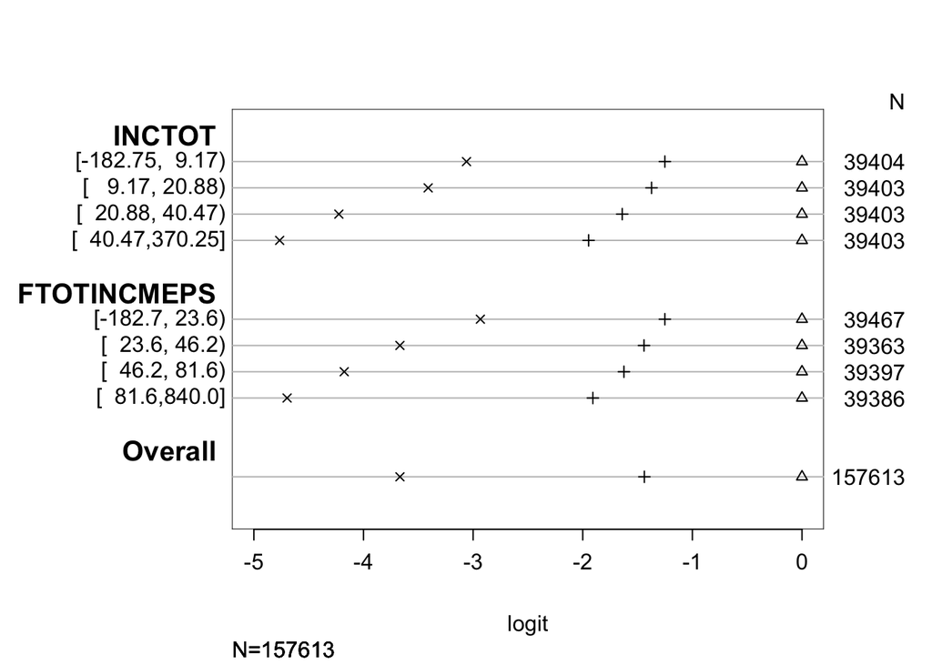

```r
s[, 4] <- s[, 4] - s[, 3]
s[, 3] <- s[, 3] - s[, 3]

 plot.3 <- plot(s, which=1:4, pch=1:4, xlab='logit', main='', xlim=range(-5,0))
```

```r
 #for the most part this is not my code see:  Ordinal Logistic Regression. UCLA: Statistical Consulting Group. from https://stats.oarc.ucla.edu/r/dae/ordinal-logistic-regression/ (accessed August 10, 2023).
```

A more legible way to understand proportional odds. These plots demonstrates how increases in a specific variable (income total) affect probabilities of being placed in each depression(PHQDEP) category.

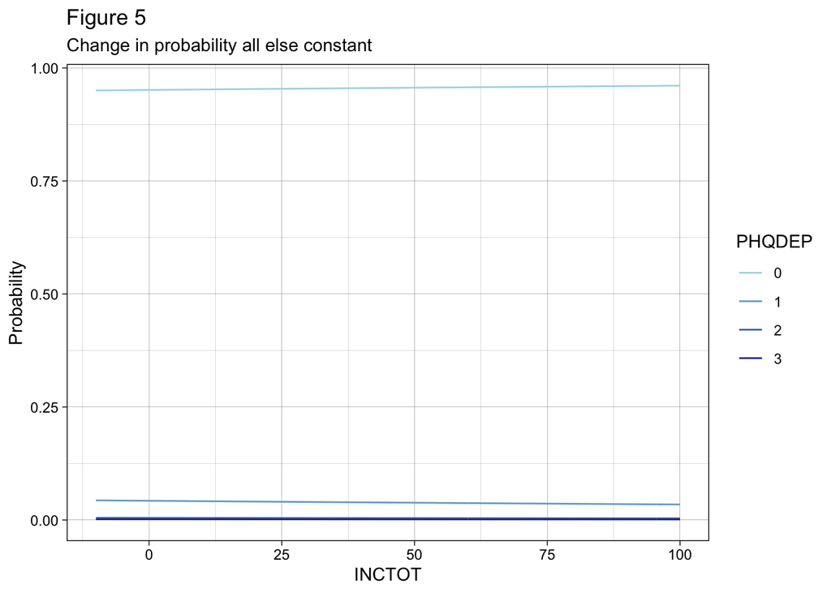

```r
#Creation of a predictions plot

model.predict <- polr(PHQDEP ~ INCTOT + FTOTINCMEPS + REGIONMEPS +SEX + MARSTAT + HEALTH +
                        EDUC + SMOKENOW + RACEA + CANCEREV + INTERVLANG + FAMSIZE + ANERVOUS,data = panel.2,Hess=TRUE)
newdat <- data.frame(
   INCTOT = rep(seq(from = -10, to = 100, length.out = 100),4),
   FTOTINCMEPS = rep(c(46.68)),
   #YEAR = rep(unique(panel$YEAR), length.out = 200),
   REGIONMEPS = rep("3"),
   SEX = rep(c("1")),
   MARSTAT= rep("20"),
   HEALTH = rep("2"),
   EDUC = rep("201"),
   SMOKENOW = rep("1"),
   RACEA = rep("100"),
   CANCEREV = rep("1"),
   INTERVLANG = rep("1"),
   FAMSIZE = rep(2),
   ANERVOUS = rep("0")
)
newdat <- cbind(newdat, predict(model.predict,newdat,type = "probs"))
lnewdat <- melt(newdat, id.vars = c("INCTOT","FTOTINCMEPS","REGIONMEPS","SEX","MARSTAT","HEALTH","EDUC",
                                    "SMOKENOW","RACEA","CANCEREV","INTERVLANG","FAMSIZE","ANERVOUS"),
                variable.name = "PHQDEP",value.name = "Probability")
ggplot(lnewdat, aes(x= INCTOT,y = Probability,color = PHQDEP))+
  labs(title = "Figure 5",subtitle = "Change in probability all else constant ")+
  geom_line()+
  theme_linedraw()+
  scale_color_manual(values = brewer.pal(11, "RdYlBu")[c(8,9,10,11)])
```

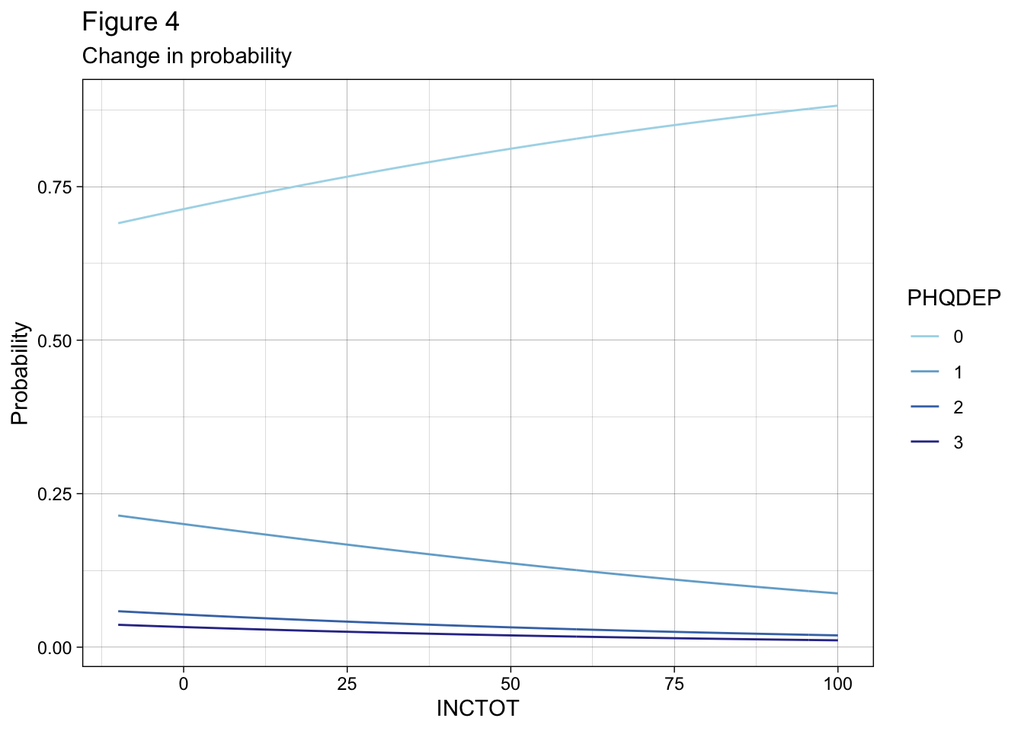

```r
model.predict1 <- polr(PHQDEP ~ INCTOT, data = panel.2, Hess = TRUE)
newdata.1 <- data.frame(
  INCTOT = rep(seq(from = -10, to = 100, length.out = 100),4)
)
newdata.1 <- cbind(newdata.1, predict(model.predict1, newdata.1,type ="probs"))
lnewdat <- melt(newdata.1, id.vars = "INCTOT",variable.name = "PHQDEP",value.name = "Probability")
ggplot(lnewdat, aes(x= INCTOT,y = Probability, color = PHQDEP))+
  labs(title = "Figure 4",subtitle = "Change in probability") +
  geom_line()+
  theme_linedraw()+
  scale_color_manual(values = brewer.pal(11, "RdYlBu")[c(8,9,10,11)])
```

```r
 #again, for the most part this is not my code see:  Ordinal Logistic Regression. UCLA: Statistical Consulting Group. from https://stats.oarc.ucla.edu/r/dae/ordinal-logistic-regression/ (accessed August 10, 2023).
```

This is a very brief overview of this analysis, for a more thorough investigation, see my paper.